# Cleaned Results

Hamza

30 September 2019

## Meta-analysis

### Calculating effect sizes

Here, we calculated our effect sizes (log response ratio lnRR) for our complete data set (all traits).

## Meta-analysis overall results (lnRR)

### 1. Calculating effect sizes (Done)

We calculated our effect sizes (log response ratio lnRR) for our complete data set (all traits).

### 2. Deciding random effects (Done)

We used AIC values to decide which random effects to use. Combining “Trait”, “Paper_ID” and “Cohort_ID” yielded the lowest AIC values.

#### 3. Running meta-analysis (overall, and then overall split by exposure type)

I conducted meta-analysis, first on the complete dataset, and then on subsetted data (split by one off and multigenerational exposure)

### Plotting overall results

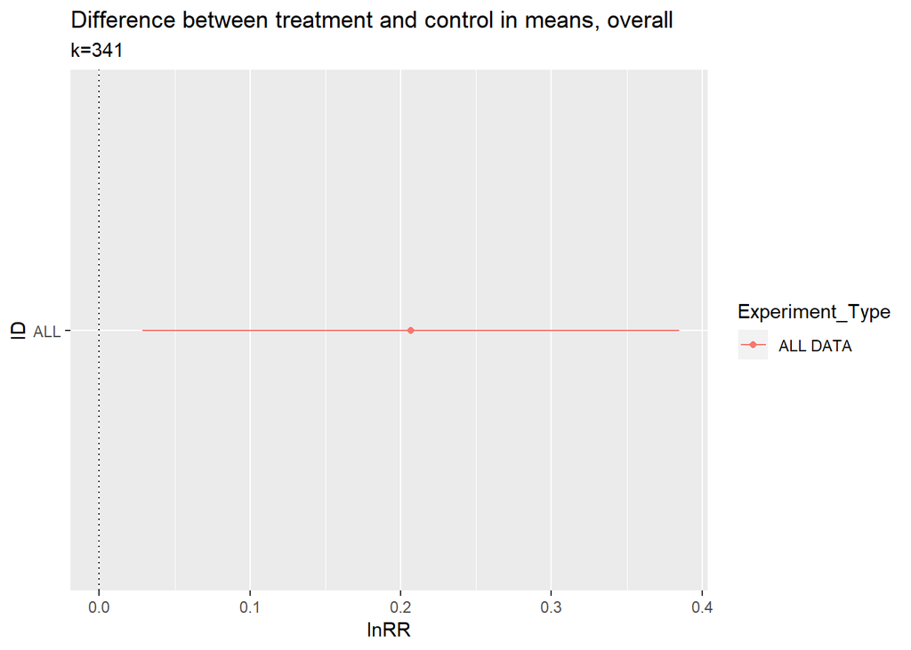

### Plotting overall results when split by multigenerational and one off exposure

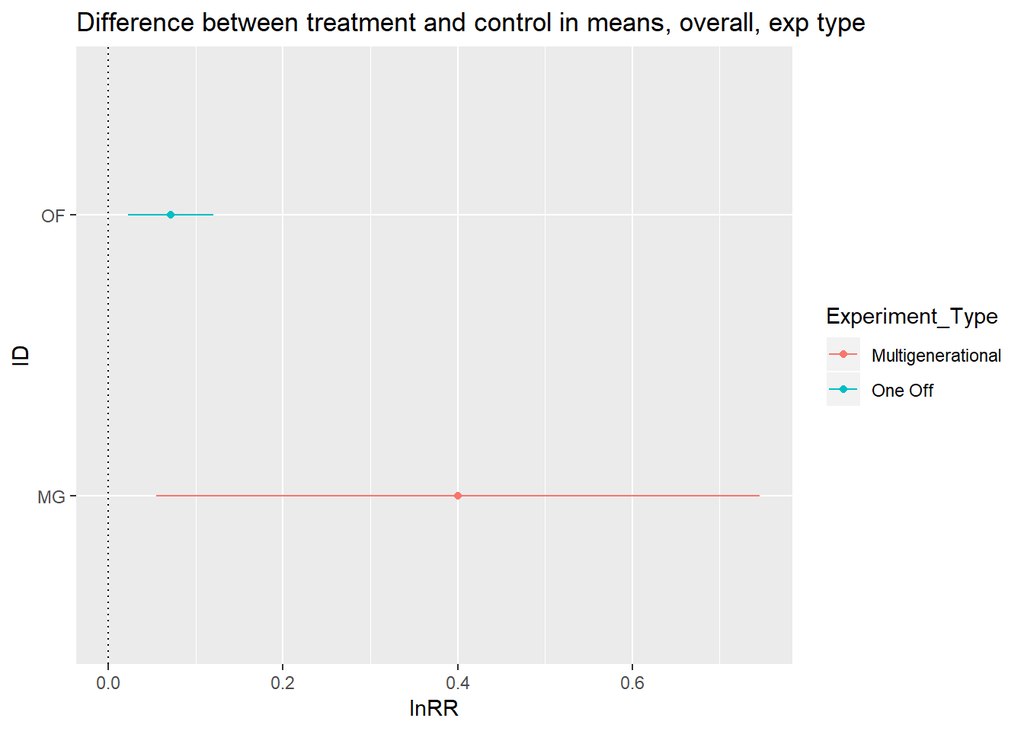

#### Running meta-analysis (Overall with moderators, and then overall split by exposure type with moderators)

### Plotting overall results with moderators

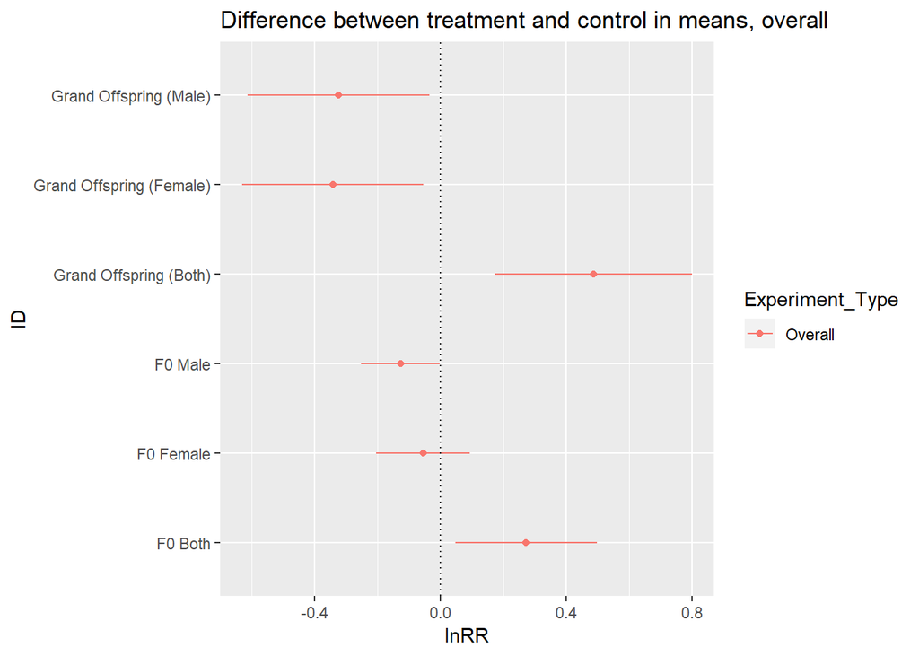

### Plotting Overall results with moderators (split by exposure type)

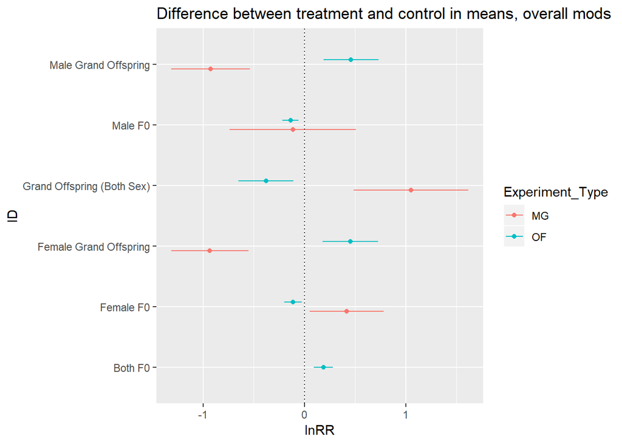

## Meta-analysis overall results (lnCVR)

### 4. Calculating effect sizes (Done)

We calculated our effect sizes (lnCVR) for our complete data set (all traits).

#### 5. Running meta-analysis for lnCVR (overall, and then overall split by exposure type)

I conducted meta-analysis using lnCVR, first on the complete dataset, and then on subsetted data (split by one off and multigenerational exposure)

### Plotting overall results lnCVR

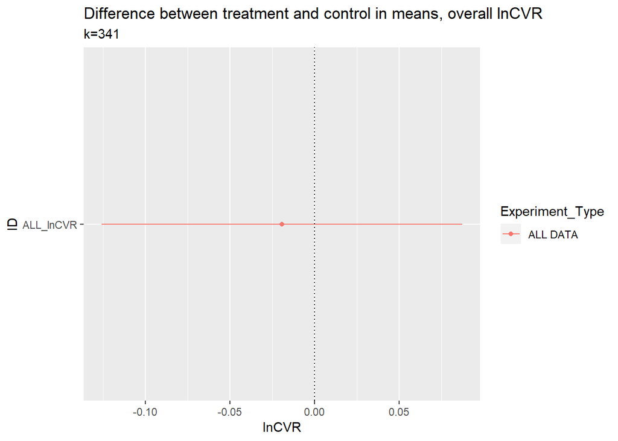

### Plotting overall results when split by multigenerational and one off exposure (lnCVR)

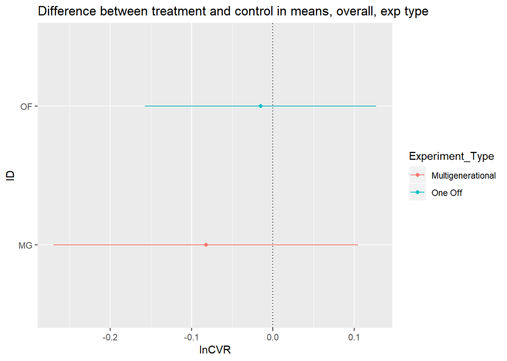

#### Running meta-analysis lnCVR (Overall with moderators, and then overall split by exposure type with moderators)

### Plotting overall results with moderators

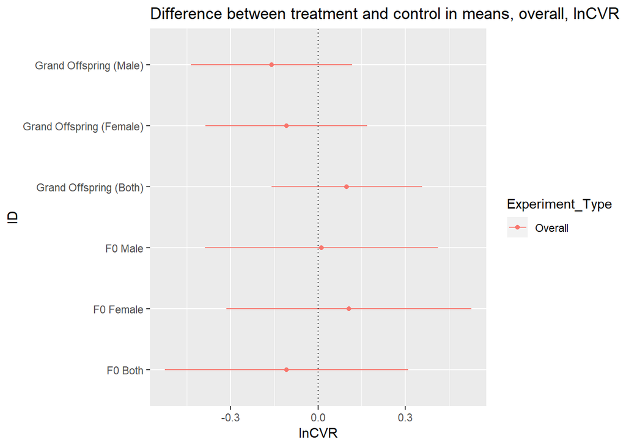

### Plotting Overall results with moderators (split by exposure type)

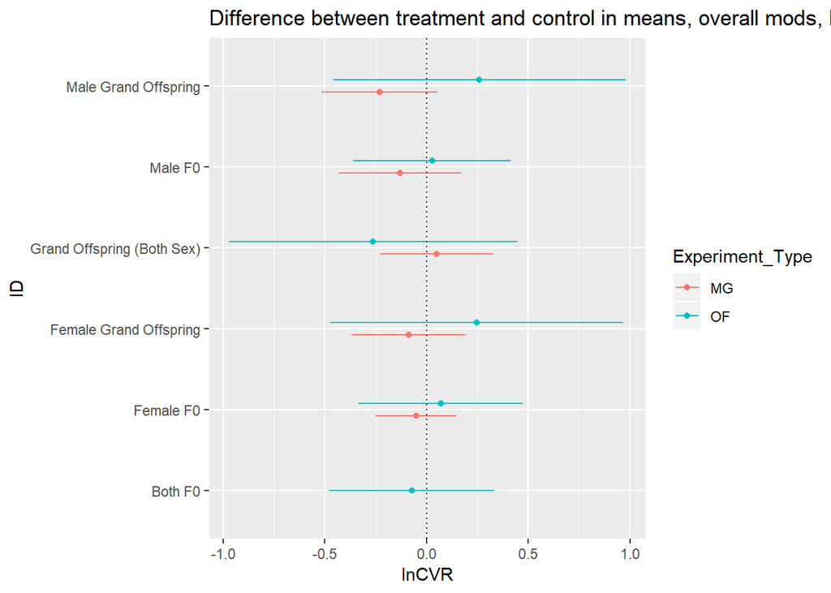